# Esophageal Cancer

Esophagectomy

Jonathan Salo MD

# Introduction

I’m Dr Jonathan Salo, a GI Cancer Surgeon in Charlotte, North Carolina.

In this video, you will learn about

- Different kinds of surgery for esophageal cancer
- Risks of surgery
- How you can reduce the risk of surgery

In another video, we’ll talk about how to choose a hospital and surgeon for your esophagectomy.

Surgery for esophageal cancer is generally performed for three different situations:

- Superficial Tumors (T1) that can’t be completely removed by endoscopy
- Localized Tumors (T2N0)
- Locally Advanced Tumors (T3 or N+) after the completion of chemotherapy and radiation

If you haven’t seen it already, this may be a good time to view the Esophageal Cancer Treatment Options video.

# Goals of Esophagectomy

.right-column[ - Remove tumor from esophagus - Remove surrounding lymph nodes - Create a new esophagus]

.left-column[

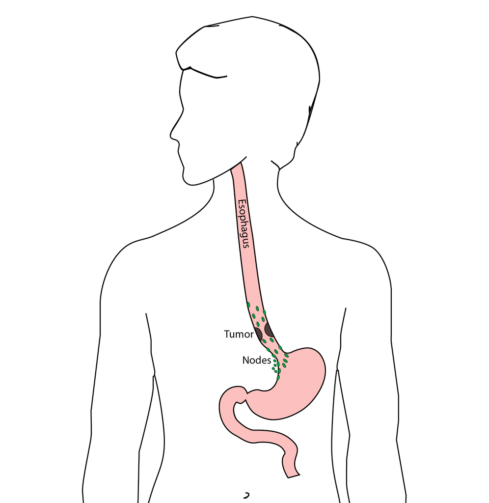

]

# Resection

.pull-left[The *Ivor Lewis* esophagectomy, shown here, removes the lower 2/3 of the esophagus, the tumor, and the surrounding lymph nodes from the chest.]

.pull-right[

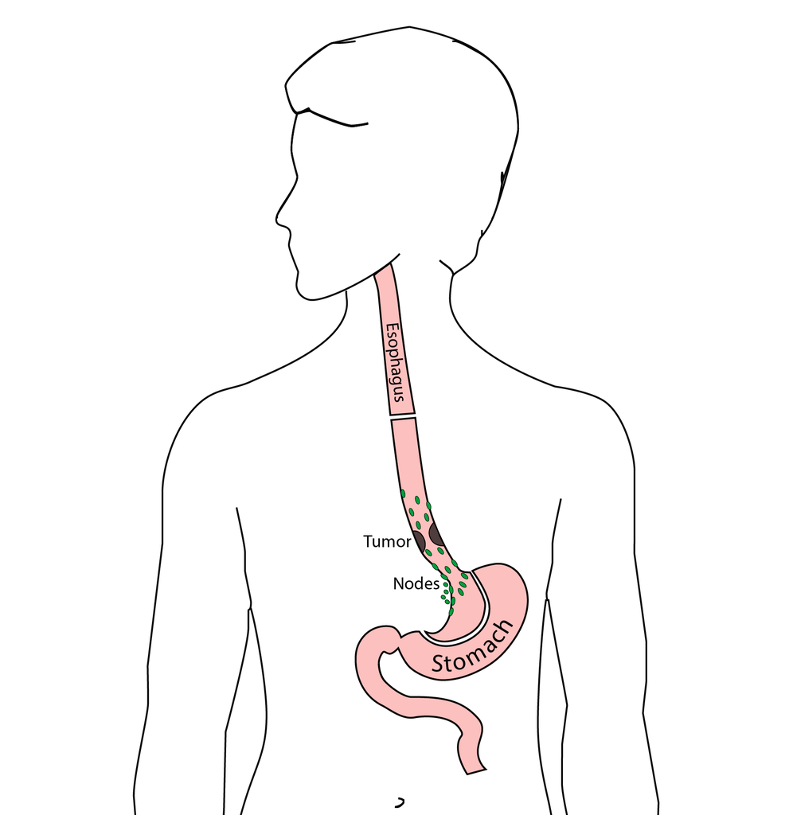

]

# Reconstruction

.pull-left[A new esophagus is created from the stomach in the abdomen by fashioning it into a tube.]

.pull-right[

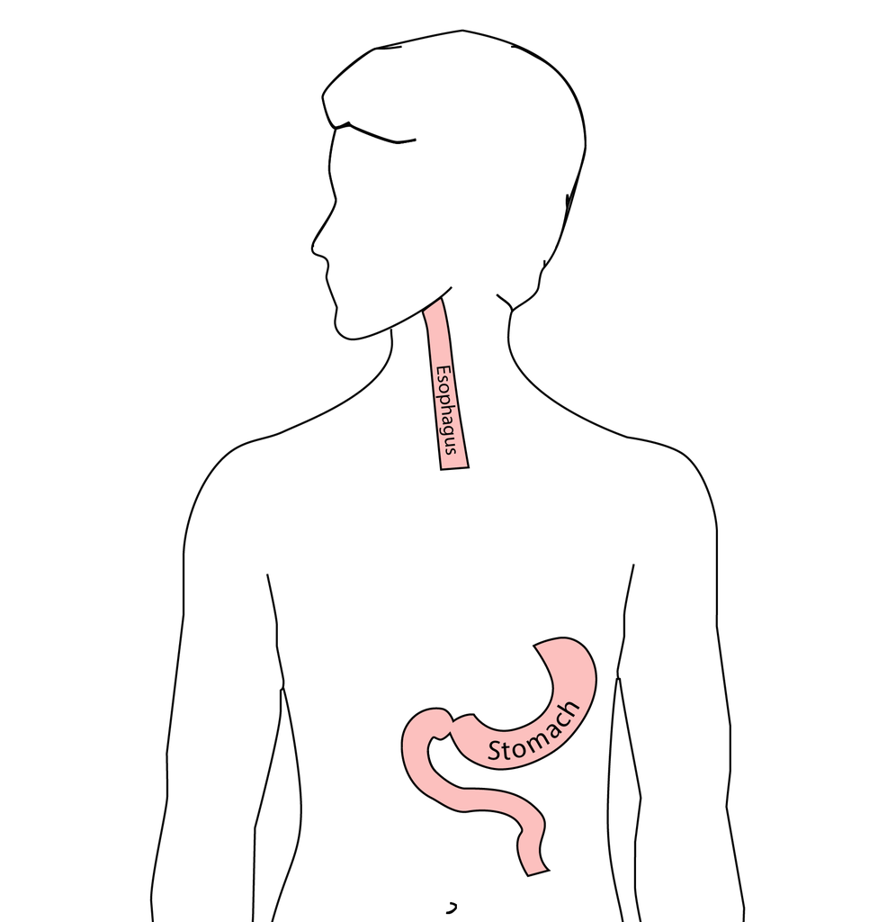

]

# Ivor Lewis esophagectomy

.pull-left[The new esophagus is now brought up into the chest. A new connection is made between the esophagus and the stomach, called an *anastomosis*.]

.pull-right[

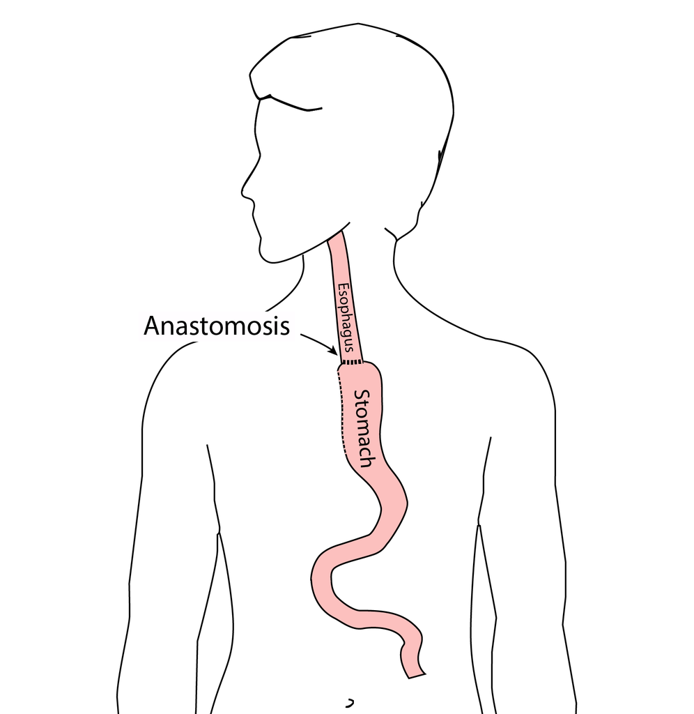

]

# Open Esophagectomy

.pull-left[Open esophagectomy uses conventional incisions in the abdomen and the right chest, and is a well-established surgical approach in use for the past 75 years.]

.pull-right[

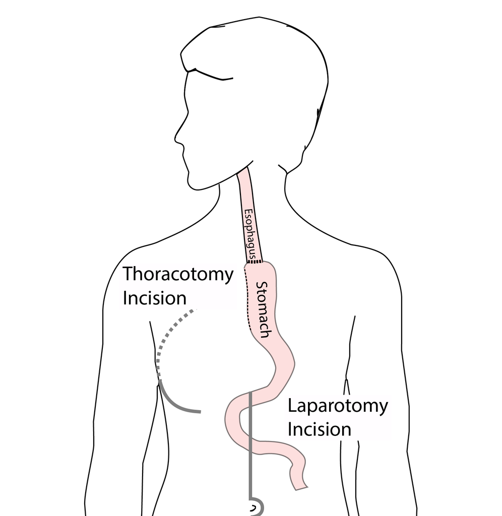

]

# Minimally-invasive Ivor Lewis

.pull-left[Mininally-invasive esophagectomy uses small incisions in the abdomen and chest and is a recent innovation.]

.pull-right[

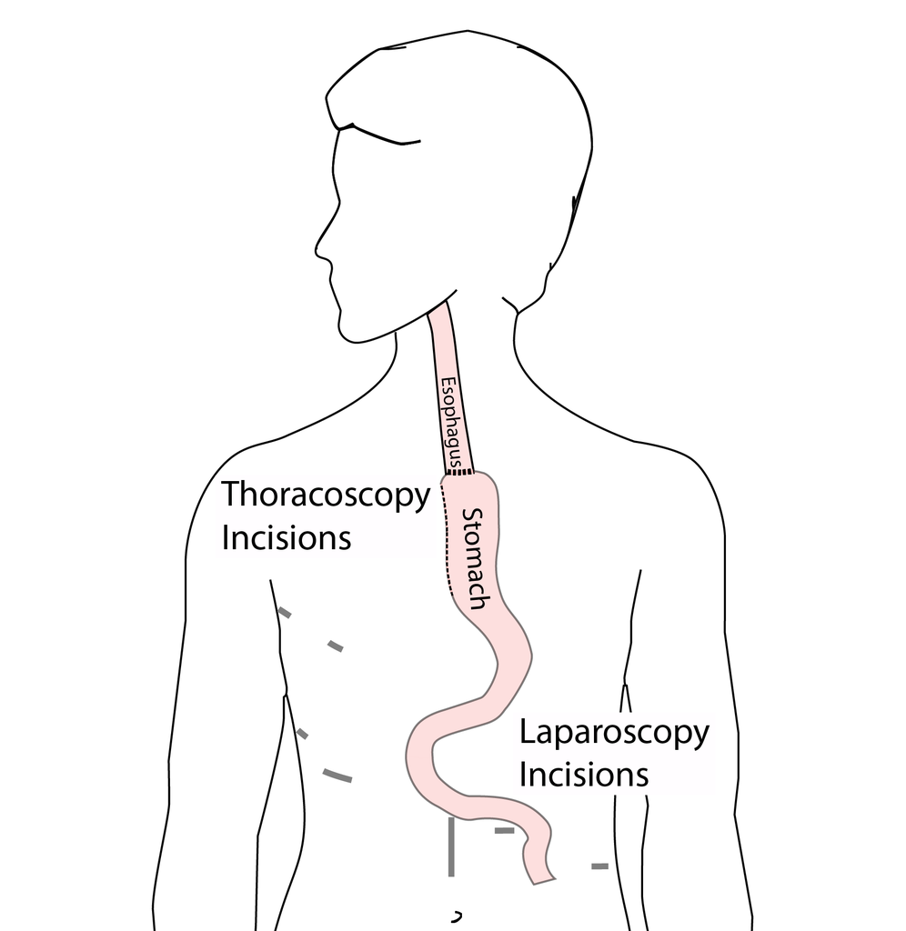

]

# Minimally-invasive Ivor Lewis

.pull-left[We have found this is the best option for most of our patients. In some cases, an open approach is still necessary. ]

.pull-right[

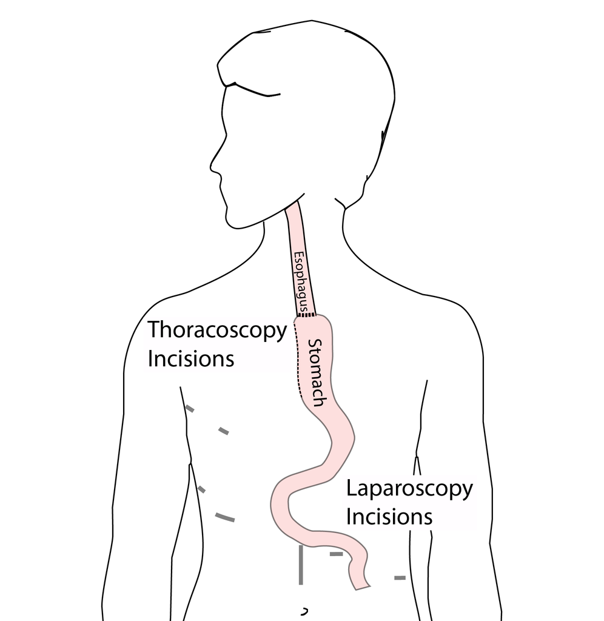

]

# Total Esophagectomy

.pull-left[For patients with tumors in the upper esophagus, we need to remove more of the esophagus]

.pull-right[

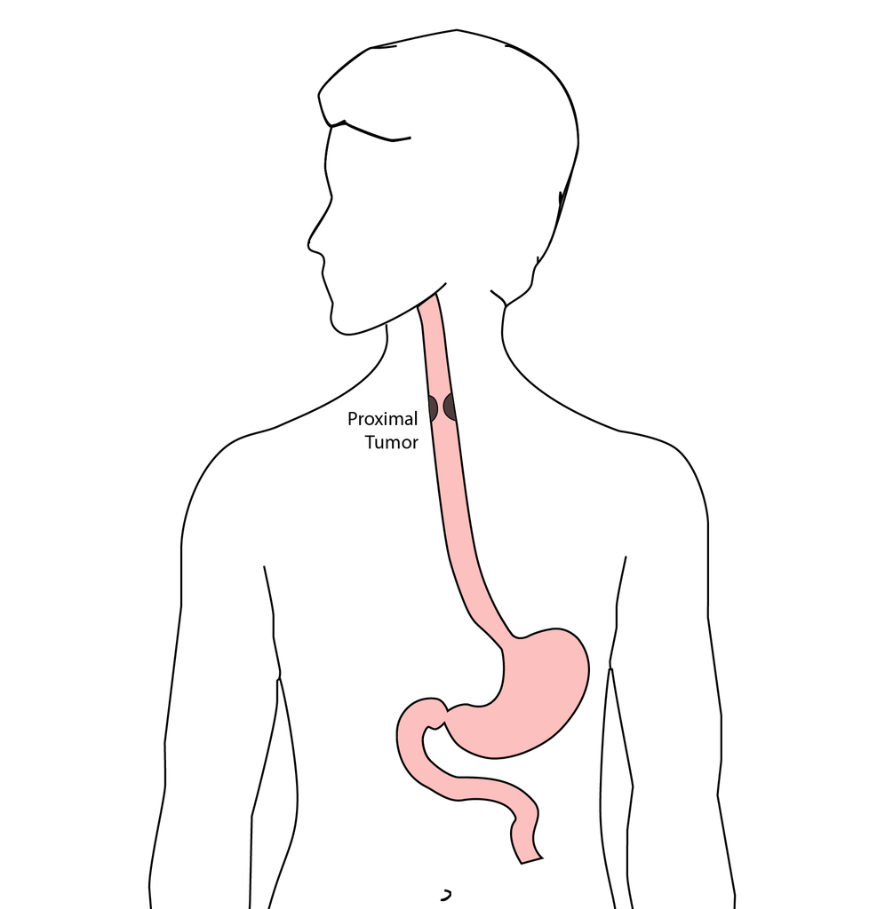

]

# Total Esophagectomy

.pull-left[For those patients, we need to remove the whole esophagus]

.pull-right[

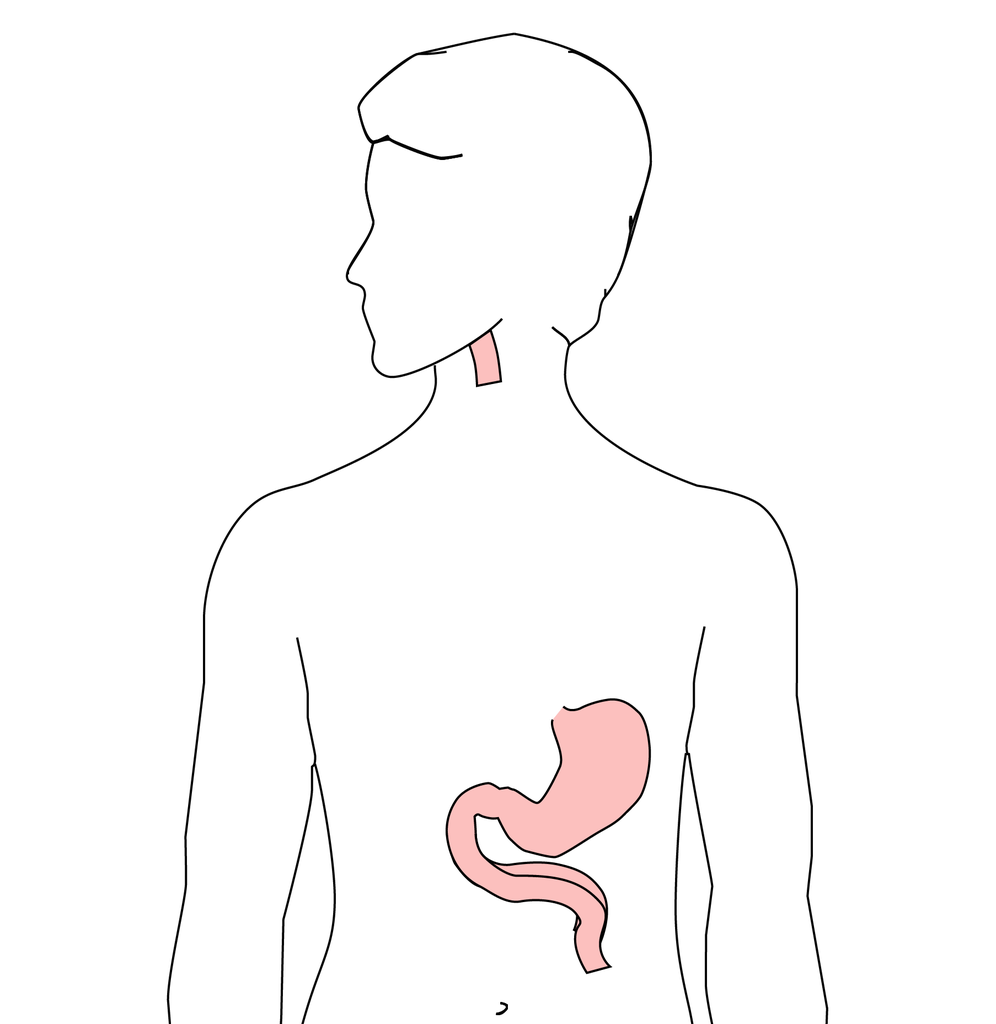

]

# Minimally-invasive McKeown Esophagectomy

.pull-left[In this case, a connection between the esophagus and the stomach is made in the neck.]

.pull-right[

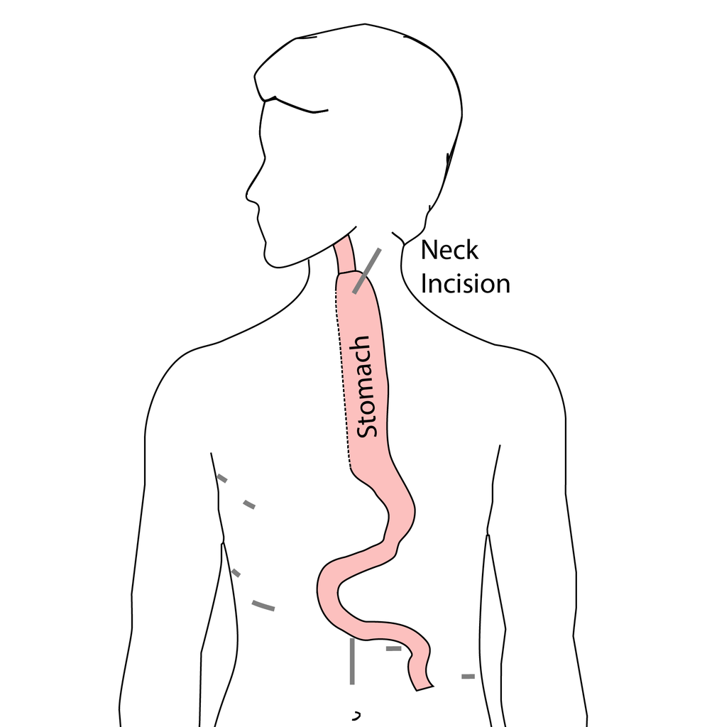

]

# Transhiatal Esophagectomy

.pull-left[Another option is a transhiatal esohagectomy, which avoids the need to make incisions in the right chest.]

.pull-right[

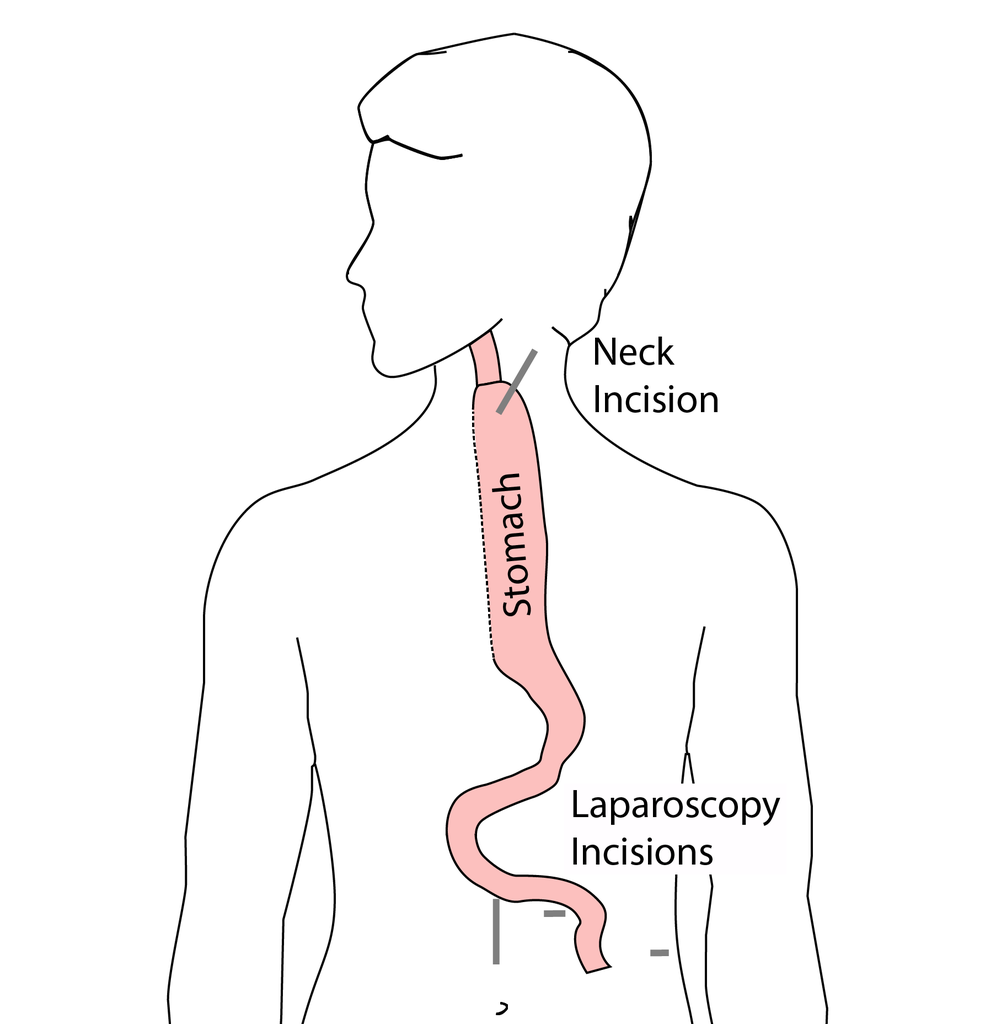

]

When you meet with your surgeon, you will have an opportunity to discuss your particular situation and their recommendation for surgery.

# Risks of Surgery

An esophagectomy is a substantial operation, and in some cases there can be postoperative complications. We’re going to talk about two of these complications and how you can reduce your risk of complications:

- Anastomotic leak
- Pneumonia

# Anastomotic Leak

.pull-left[The anastomosis is surigcal connection between the esophagus and the stomach. ]

.pull-right[

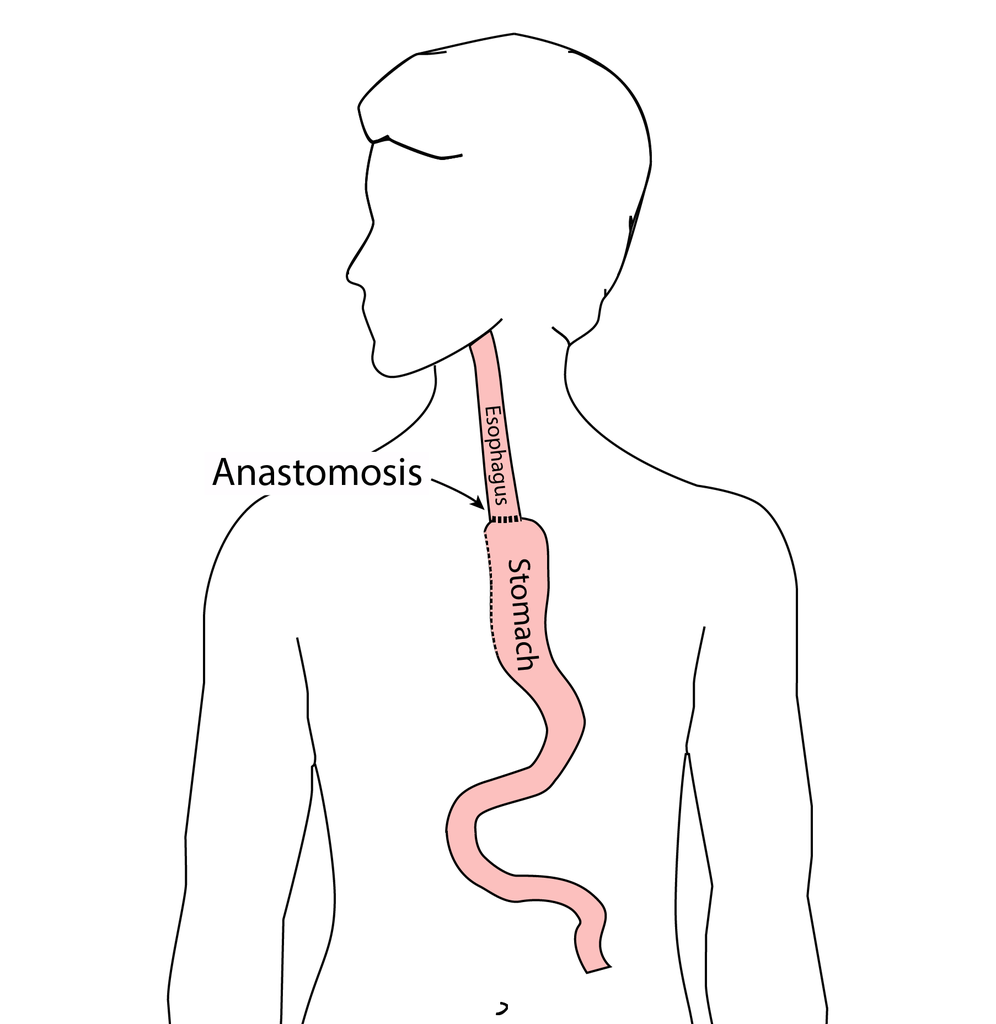

]

# Anastomotic Leak

.pull-left[If anastomosis does not heal properly, this can cause a leakage of fluid from the esophagus, called an anastomotic leak. If this happens, an infection can occur in the mediastinum, which is the space near the heart between the lungs.]

.pull-right[

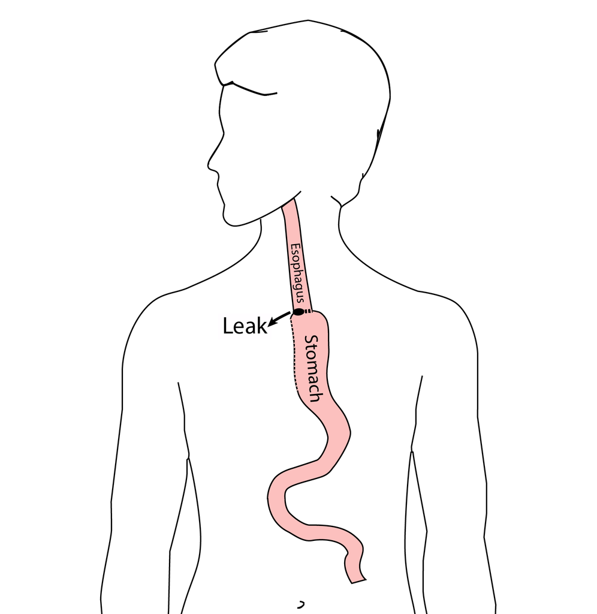

]

# Anastomotic Leak

In some cases, the leak will heal on its own, but other cases may require additional procedures or even surgery. The risk of leak depends upon the operation performed but also depends upon the experience of the surgeon. At the end of this video we have a link to a video about how to choose a hospital and a surgeon, which talks further about the risks of a leak.

# Pneumonia

.pull_right[

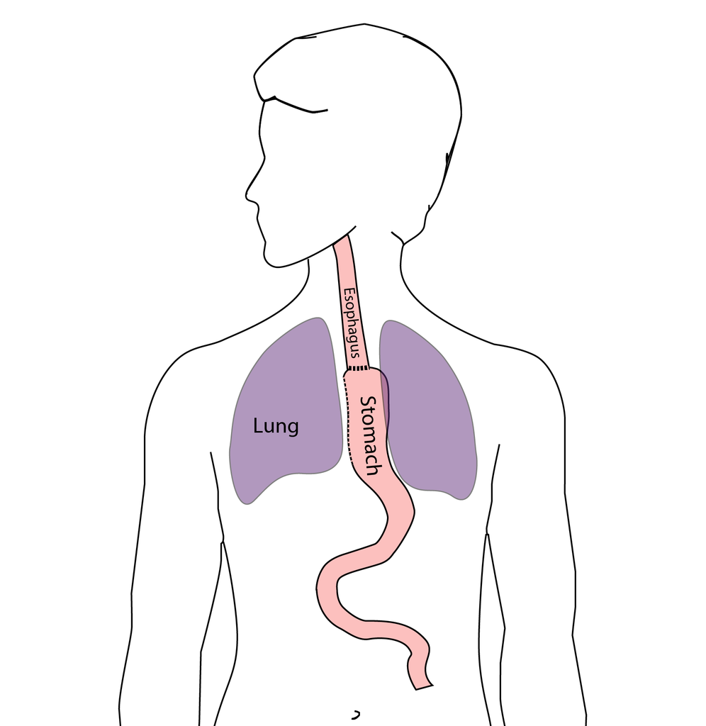

]

# Preventing Pneumonia

In normal circumstances, secretions from the mouth and throat aren’t able to enter the lungs because we clear our throat and if secretions do get into our airway, we can simply cough and keep those secretions out of our lungs. This happens constantly without our thinking about it.

After esophagectomy, however, there is a tendency for secretions to enter the airway, and if you can’t clear them, there is a risk that pneumonia will set in.

There are two important ways that pneumonia can be prevented:

- Deep breathing
- Walking

# Deep breathing and coughing

After surgery, it’s important to breathe deeply to help your lungs recover after surgery. Deep breathing make the cough more effective and helps clear secretions. After surgery, deep breathing and coughing can be uncomfortable, so controlling your pain will be an important part of your recovery.

# Walking

Walking after surgery is also an important way to help your lungs recover as well. When we walk, it’s easier for our lungs to function, and again, it makes the cough more frequently.

# Preventing Pneumonia

How can we prevent pneumonia? Believe it or not, I can tell who is more likely to develop pneumonia after surgery when I first meet them and shake their hand. Someone with a firm handshake has a lower risk of pneumonia. We think this is because someone with a firm handshake has good muscle tone, and someone with good muscle tone probably has good function of the muscles between the ribs so that they have a nice strong cough and can prevent pneumonia.

# Strength

In our clinic, we actually measure your strength with a hand-held strength gauge called a dynamometer. Based upon these measurements, we can identify patients who may be at risk of pneumonia.

# Patient Strength and Esophagectomy Outcomes

About half of our patients have good strength, shown in green. A quarter are have low strength, shown in red Another quarter are in the middle, shown in yellow

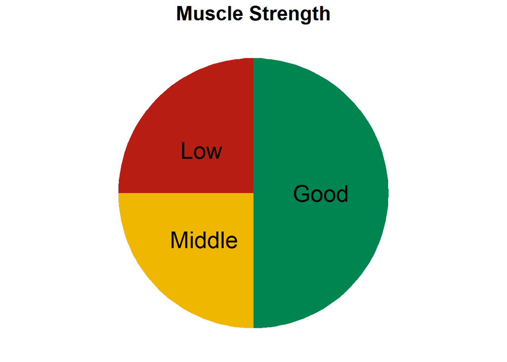

# Pneumonia

Overall, the risk of pneumonia is about 10% in our patients who undergo esophagectomy. 90% of patients never experience pneumonia, but 10% will have pneumonia after surgery.

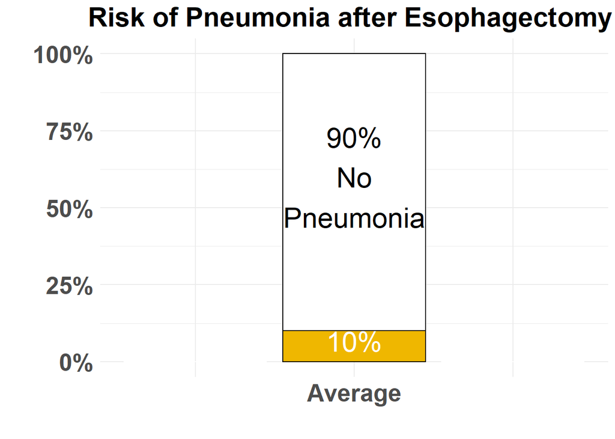

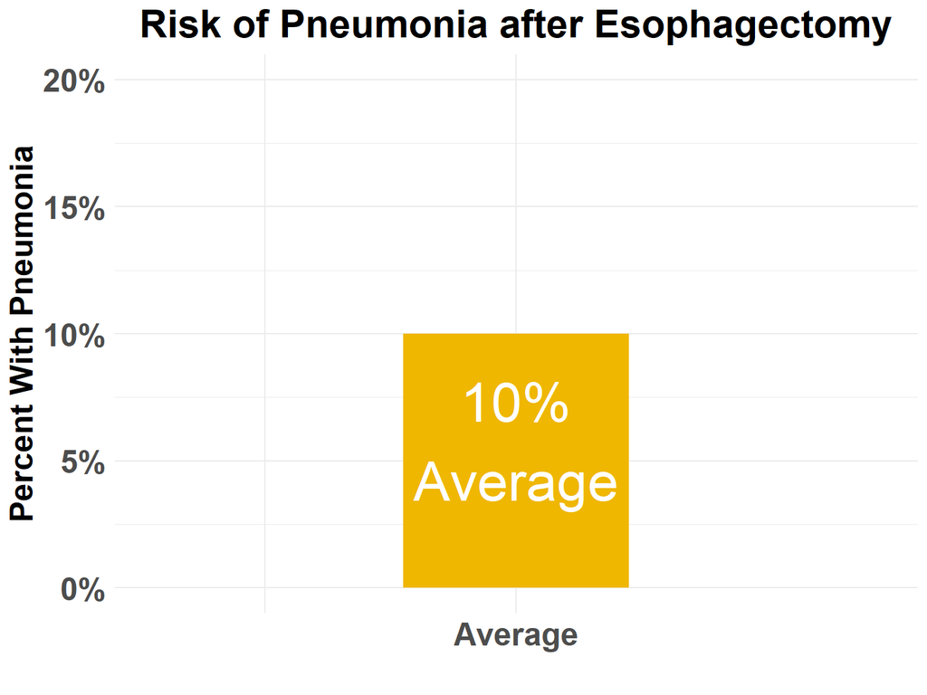

However the risk of pneumonia is not the same for everyone. Even though the average risk is 10%, the risk is much higher for our patients with low muscle strength and much lower for patients with good muscle strength.

For the half of our patients with good muscle strength, the risk of pneumonia is about 5%. On the other hand, the risk of pneumonia is 20% in the quarter of our patients who have low muscle strength.

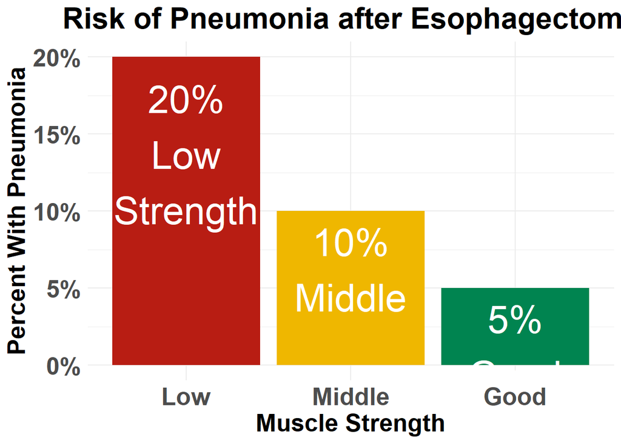

# Muscle Strength and Risk after Esophagectomy

.pull-left[The results of our research suggest a simple answer: The risk of pneumonia is related to a patient’s muscle strength.]

.pull-right[

[figure not shown]

]

.pull-left[Now this doesn’t mean that you need to look like this to prevent pneumonia after your esophagectomy]

.pull-right[

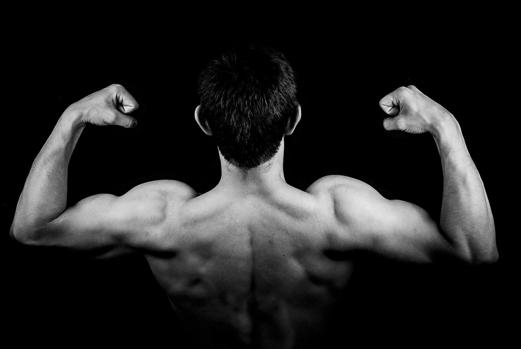

]

The good news is that you can increase your muscle strength before surgery in two very simple ways:

- Good nutrition with adequate intake of protein
- Exercise

# Good News

The good news is that with proper nutrition and exercise, you can increase your muscle strength, and we have good reason to believe this will reduce your risk of complications after esophagectomy.

When you meet with your surgery team, be sure to ask them about pain control after surgery and how you can increase your muscle strength

I would love to hear you comments about this video, so please leave a comment below. We’re constantly creating new videos, so please subscribe to be notified of new videos when we post them.